# Chapter 5: Dimensionality Reduction

Henri V

2023-12-02

# Chapter 5: Dimensionality Reduction

## Data wrangling continues

```r
require("here");require("tidyverse")
#source(here("Scripts/create_human.R"))
rm(list=c("gii", "hd"))
```

**Task 1: Explore the structure and the dimensions of the ‘human’ data and describe the dataset briefly, assuming the reader has no previous knowledge of it (this is now close to the reality, since you have named the variables yourself). (1 point)**

- Load the previously-created Human.csv dataset
- This has been created by merging Human Development Index and Gender Inequality Index data.

```r
library(readr)
human <- read_csv("Data/human.csv")
```

```
## ──────────────────────────────────────────────────────── Delimiter: "," chr
## (1): Country dbl (19): ...1, HDI_Rank, HDI, LifeExp, EduExp, EduMean, GNI,
## GNI_minus_HDIr...
```

```r
human<-select(human, 2:length(human))
```

- Metadata for the human dataset can be found at: https://hdr.undp.org/data-center/documentation-and-downloads. See tables 1 and 5.
- The data contains country specific information on Human Development Index values, and associated variables describing the countries.
- In the Human Development data, the following variables are included. New, one-word names for these are provided in parentheses and quotes.
  - HDI ranking in relation to the others
  - Country name
  - Human Development Index value (new name: “HDI”)
  - Life expectancy at birth (“LifeExp”)
  - Expected years of schooling (“EduExp”)
  - Mean years of schooling (“EduMean”)
  - Gross national income (GNI) per capita (“GNI”)
  - GNI per capita rank minus HDI rank (“GNI_minus_HDIrank”)
- Variables from the Gender Inequality Index data are:
  - Country’s ranking in terms of the Gender Inequality Index (“GII_Rank”)
  - Country’s Gender Inequality Index ranking (“GII”)
  - Maternal Mortality Ratio by country (“MMRatio”)
  - Adolescent birth rate, i.e. births per 1,000 women ages 15–19 (“ABRate”)
  - Places in parliament held by women (“PRP”)
  - Population with at least some secondary education, %, for women and men respectively (“PSECED_F” and “PSECED_M”)
  - Labor force participation rate, %, for women and men respecively (“LFPR_F” and “LFPR_M”)
- Calculated variables are:
  - Ratio of female and male populations with secondary education in each country (“PSECED_FM_Ratio”)
  - Ratio of labor force participation of females and males in each country (“LaborFM_ratio”)
- Check dimensions and structure:

```r
str(human)
```

```
## tibble [195 × 19] (S3: tbl_df/tbl/data.frame)
##  $ HDI_Rank         : num [1:195] 1 2 3 4 5 6 6 8 9 9 ...
##  $ Country          : chr [1:195] "Norway" "Australia" "Switzerland" "Denmark" ...
##  $ HDI              : num [1:195] 0.944 0.935 0.93 0.923 0.922 0.916 0.916 0.915 0.913 0.913 ...
##  $ LifeExp          : num [1:195] 81.6 82.4 83 80.2 81.6 80.9 80.9 79.1 82 81.8 ...
##  $ EduExp           : num [1:195] 17.5 20.2 15.8 18.7 17.9 16.5 18.6 16.5 15.9 19.2 ...
##  $ EduMean          : num [1:195] 12.6 13 12.8 12.7 11.9 13.1 12.2 12.9 13 12.5 ...
##  $ GNI              : num [1:195] 64992 42261 56431 44025 45435 ...
##  $ GNI_minus_HDIrank: num [1:195] 5 17 6 11 9 11 16 3 11 23 ...
##  $ GII_Rank         : num [1:195] 1 2 3 4 5 6 6 8 9 9 ...
##  $ GII              : num [1:195] 0.067 0.11 0.028 0.048 0.062 0.041 0.113 0.28 0.129 0.157 ...
##  $ MMRatio          : num [1:195] 4 6 6 5 6 7 9 28 11 8 ...
##  $ ABRate           : num [1:195] 7.8 12.1 1.9 5.1 6.2 3.8 8.2 31 14.5 25.3 ...
##  $ PRP              : num [1:195] 39.6 30.5 28.5 38 36.9 36.9 19.9 19.4 28.2 31.4 ...
##  $ PSECED_F         : num [1:195] 97.4 94.3 95 95.5 87.7 96.3 80.5 95.1 100 95 ...
##  $ PSECED_M         : num [1:195] 96.7 94.6 96.6 96.6 90.5 97 78.6 94.8 100 95.3 ...
##  $ LFPR_F           : num [1:195] 61.2 58.8 61.8 58.7 58.5 53.6 53.1 56.3 61.6 62 ...
##  $ LFPR_M           : num [1:195] 68.7 71.8 74.9 66.4 70.6 66.4 68.1 68.9 71 73.8 ...
##  $ PSECED_FM_Ratio  : num [1:195] 1.007 0.997 0.983 0.989 0.969 ...
##  $ LaborFM_ratio    : num [1:195] 0.891 0.819 0.825 0.884 0.829 ...
```

```r
dim(human)
```

```
## [1] 195  19
```

**Task 2: Exclude unneeded variables: keep only the columns matching the following variable names (described in the meta file above): “Country”, “Edu2.FM”, “Labo.FM”, “Edu.Exp”, “Life.Exp”, “GNI”, “Mat.Mor”, “Ado.Birth”, “Parli.F” (1 point).**

```r
# Create a vector of vars to keep. Remember that you renamed your vars differently, copypasting the above names into a vector won't work:

keepers<-c("Country",
  "PSECED_FM_Ratio",
  "LaborFM_ratio",
  "EduExp",
  "LifeExp",
  "GNI",
  "MMRatio",
  "ABRate",
  "PRP")

# Select only these vars from human dataframe
human<-human %>% select(all_of(keepers))
```

**Task 3: Remove all rows with missing values (1 point).**

- Any country (row) with ANYTHING NA will be dropped.

```r
human<-filter(human, complete.cases(human)==T)
```

**Task 4: Remove the observations which relate to regions instead of countries. (1 point)**

- Seven final rows are regions instead of countries, dropping them

```r
human<-human %>% slice(1:(nrow(human)-7))
```

```r
dim(human)
```

```
## [1] 155   9
```

*Task 5 The data should now have 155 observations and 9 variables (including the “Country” variable). Save the human data in your data folder. You can overwrite your old ‘human’ data. (1 point).*

```r
dim(human)
```

```
## [1] 155   9
```

- Dimensions 155 x 9 as requested.
- Saving to Data, but I will not overwrite, so that the original remains if I need to revert to it.

```r
library(here)
write.csv(human, file=here("Data/human2.csv"))
```

## Analysis phase

**Task 1: Move the country names to rownames (see Exercise 5.5). Show a graphical overview of the data and show summaries of the variables in the data. Describe and interpret the outputs, commenting on the distributions of the variables and the relationships between them. (0-3 points)**

- Setting country names as rownames

```r
library(tibble)
human_<-column_to_rownames(human, "Country")
```

- Graphical summary

Commentary:

- Basically all variables have a skewed distribution, most often towars small values,
  - Except for Female-male ratio in the workforce, and life expectency, both of which skew towards high values
- Bear in mind that these are non-standardized values, measured at different scales and having very different ranges as well.
- Multiple strong correlations, some of which are highlighted here:
  - Rate of adolescent births correlates negatively with Gross national income (very young mothers more common in less affluent nations)
  - Maternal mortality rates and adolescent births strongly correlate, positive relationship
  - Life expectency increases with increasing GNI, as expected
  - Expected years of schooling correlates strongly with GNI & life expectency (positive corr.), and negatively with adolescent births and maternal mortality
- Looks to me that there might be potential to divide this set of countries into the “Affluent, progressive and educated” and the “less fortunate” subsets, the latter of which is characterized by low GDPs, low education rates, high maternal mortalities and rates of adolescent birth…

```r
library(GGally)
```

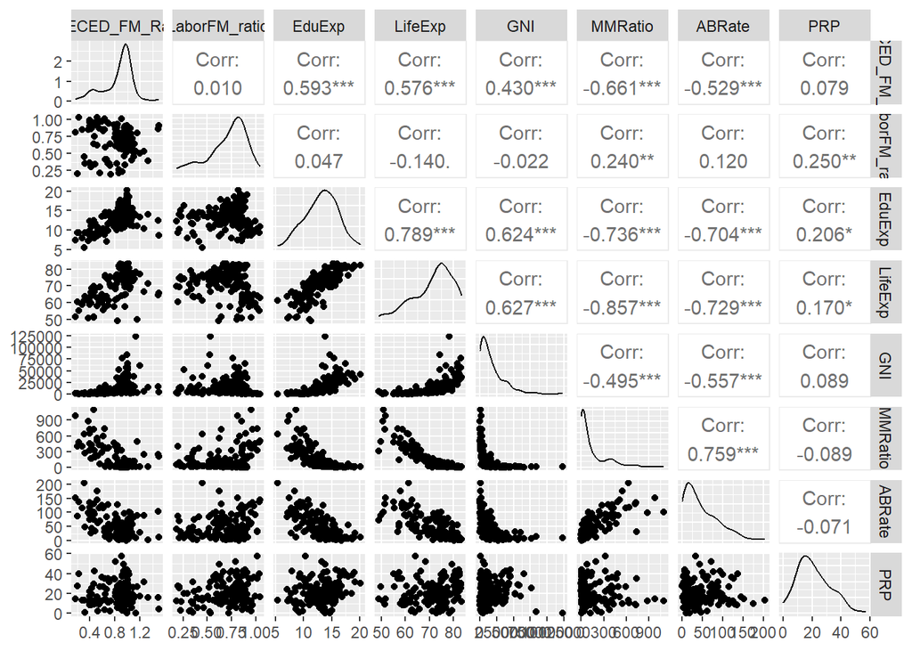

```r
ggpairs(human_, progress = F)
```

- Table-form summary

```r
summary(human_)
```

```
##  PSECED_FM_Ratio  LaborFM_ratio        EduExp         LifeExp
##  Min.   :0.1717   Min.   :0.1857   Min.   : 5.40   Min.   :49.00
##  1st Qu.:0.7264   1st Qu.:0.5984   1st Qu.:11.25   1st Qu.:66.30
##  Median :0.9375   Median :0.7535   Median :13.50   Median :74.20
##  Mean   :0.8529   Mean   :0.7074   Mean   :13.18   Mean   :71.65
##  3rd Qu.:0.9968   3rd Qu.:0.8535   3rd Qu.:15.20   3rd Qu.:77.25
##  Max.   :1.4967   Max.   :1.0380   Max.   :20.20   Max.   :83.50
##       GNI            MMRatio           ABRate            PRP
##  Min.   :   581   Min.   :   1.0   Min.   :  0.60   Min.   : 0.00
##  1st Qu.:  4198   1st Qu.:  11.5   1st Qu.: 12.65   1st Qu.:12.40
##  Median : 12040   Median :  49.0   Median : 33.60   Median :19.30
##  Mean   : 17628   Mean   : 149.1   Mean   : 47.16   Mean   :20.91
##  3rd Qu.: 24512   3rd Qu.: 190.0   3rd Qu.: 71.95   3rd Qu.:27.95
##  Max.   :123124   Max.   :1100.0   Max.   :204.80   Max.   :57.50
```

- As the values are non-standardized, all of them exhibit very different ranges.
- Countries clearly have very different conditions. For instance, Life expectancies are at worst merely 49. Similarly broad range is seen for GNI.
- If the data is sorted in an ascending order for these vars, a bleak picture is drawn for the “global south”.

```r
head(arrange(human_, LifeExp, GNI), n= 20)
```

```
##                                    PSECED_FM_Ratio LaborFM_ratio EduExp LifeExp
## Swaziland                                0.8423077     0.6131285   11.3    49.0
## Lesotho                                  1.1526316     0.8027211   11.1    49.8
## Central African Republic                 0.3782772     0.8531140    7.2    50.7
## Sierra Leone                             0.4608295     0.9521739    8.6    50.9
## Côte d'Ivoire                            0.4651163     0.6437346    8.9    51.5
## Chad                                     0.1717172     0.8080808    7.4    51.6
## Mozambique                               0.2258065     1.0326087    9.3    55.1
## Cameroon                                 0.6103152     0.8307292   10.4    55.5
## Burundi                                  0.6385542     1.0158537   10.1    56.7
## South Africa                             0.9578393     0.7355372   13.6    57.4
## Zimbabwe                                 0.7854839     0.9275362   10.9    57.5
## Mali                                     0.5099338     0.6240786    8.4    58.0
## Uganda                                   0.6835821     0.9570707    9.8    58.5
## Congo (Democratic Republic of the)       0.3950617     0.9658470    9.8    58.7
## Burkina Faso                             0.2812500     0.8566667    7.8    58.7
## Benin                                    0.4185185     0.8633461   11.1    59.6
## Togo                                     0.3995037     0.9913899   12.2    59.7
## Zambia                                   0.5863636     0.8539720   13.5    60.1
## Gambia                                   0.5523810     0.8709288    8.8    60.2
## Afghanistan                              0.1979866     0.1987421    9.3    60.4
##                                      GNI MMRatio ABRate  PRP
## Swaziland                           5542     310   72.0 14.7
## Lesotho                             3306     490   89.4 26.8
## Central African Republic             581     880   98.3 12.5
## Sierra Leone                        1780    1100  100.7 12.4
## Côte d'Ivoire                       3171     720  130.3  9.2
## Chad                                2085     980  152.0 14.9
## Mozambique                          1123     480  137.8 39.6
## Cameroon                            2803     590  115.8 27.1
## Burundi                              758     740   30.3 34.9
## South Africa                       12122     140   50.9 40.7
## Zimbabwe                            1615     470   60.3 35.1
## Mali                                1583     550  175.6  9.5
## Uganda                              1613     360  126.6 35.0
## Congo (Democratic Republic of the)   680     730  135.3  8.2
## Burkina Faso                        1591     400  115.4 13.3
## Benin                               1767     340   90.2  8.4
## Togo                                1228     450   91.5 17.6
## Zambia                              3734     280  125.4 12.7
## Gambia                              1507     430  115.8  9.4
## Afghanistan                         1885     400   86.8 27.6
```

**Task 2: Perform principal component analysis (PCA) on the raw (non-standardized) human data. Show the variability captured by the principal components. Draw a biplot displaying the observations by the first two principal components (PC1 coordinate in x-axis, PC2 coordinate in y-axis), along with arrows representing the original variables. (0-2 points)**

- PCA on un-standardized data

```r
pca_human_nonstandard <- prcomp(human_)
summary(pca_human_nonstandard)
```

```
## Importance of components:
##                              PC1      PC2   PC3   PC4   PC5   PC6    PC7    PC8
## Standard deviation     1.854e+04 185.5219 25.19 11.45 3.766 1.566 0.1912 0.1591
## Proportion of Variance 9.999e-01   0.0001  0.00  0.00 0.000 0.000 0.0000 0.0000
## Cumulative Proportion  9.999e-01   1.0000  1.00  1.00 1.000 1.000 1.0000 1.0000
```

- In this nonstandardized set, PC1 captures practically all of the variance by itself…
- This is an effect of nonstandardization, as the ranges of all vars are currently massively different…

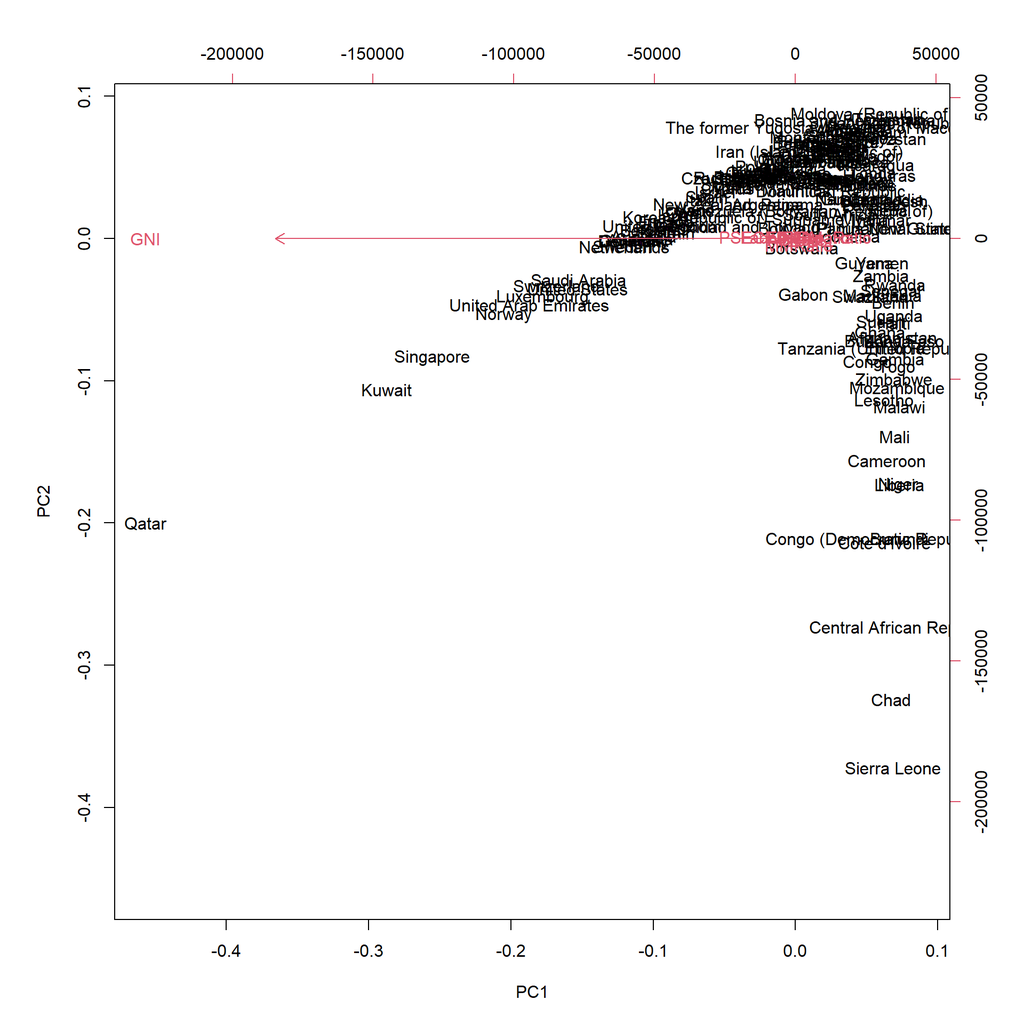

```r
biplot(pca_human_nonstandard, choices = 1:2)
```

Some interpretation. This is asked for in the next task:

- As the data is not standardized, every variable is measured at a different scale. Only GNI is now highlighted as a contributing variable, as it range is massively higher than that of any other var and thus dominates the analysis.
- Basically, the data is now reduced into the “very wealthy countries” and “everybody else”.
- GNI is negatively associated with the 1st PC, vector points towards small PC1 values (see also “loadings” table below, it shows essentially the same thing).
  - As GNI increases, PC 1 values get smaller.

```r
library(loadings)

pca_loading(pca_human_nonstandard)
```

```
## Standard deviations (1, .., p=8):
## [1] 1.854416e+04 1.855219e+02 2.518701e+01 1.145441e+01 3.766241e+00
## [6] 1.565912e+00 1.912052e-01 1.591112e-01
##
## Rotation (n x k) = (8 x 8):
##                           PC1           PC2           PC3           PC4
## PSECED_FM_Ratio -5.607472e-06  0.0006713951 -3.412027e-05 -2.736326e-04
## LaborFM_ratio    2.331945e-07 -0.0002819357  5.302884e-04 -4.692578e-03
## EduExp          -9.562910e-05  0.0075529759  1.427664e-02 -3.313505e-02
## LifeExp         -2.815823e-04  0.0283150248  1.294971e-02 -6.752684e-02
## GNI             -9.999832e-01 -0.0057723054 -5.156742e-04  4.932889e-05
## MMRatio          5.655734e-03 -0.9916320120  1.260302e-01 -6.100534e-03
## ABRate           1.233961e-03 -0.1255502723 -9.918113e-01  5.301595e-03
## PRP             -5.526460e-05  0.0032317269 -7.398331e-03 -9.971232e-01
##                           PC5           PC6           PC7           PC8
## PSECED_FM_Ratio -0.0022935252  2.180183e-02  6.998623e-01  7.139410e-01
## LaborFM_ratio    0.0022190154  3.264423e-02  7.132267e-01 -7.001533e-01
## EduExp           0.1431180282  9.882477e-01 -3.826887e-02  7.776451e-03
## LifeExp          0.9865644425 -1.453515e-01  5.380452e-03  2.281723e-03
## GNI             -0.0001135863 -2.711698e-05 -8.075191e-07 -1.176762e-06
## MMRatio          0.0266373214  1.695203e-03  1.355518e-04  8.371934e-04
## ABRate           0.0188618600  1.273198e-02 -8.641234e-05 -1.707885e-04
## PRP             -0.0716401914 -2.309896e-02 -2.642548e-03  2.680113e-03
```

**Task 3: Standardize the variables in the human data and repeat the above analysis. Interpret the results of both analysis (with and without standardizing). Are the results different? Why or why not? Include captions (brief descriptions) in your plots where you describe the results by using not just your variable names, but the actual phenomena they relate to. (0-4 points)**

- Standardization, to make the vars comparable. This process, already seen during previous weeks, centers the variables (mean = 0 for all of them), eliminating the “comparing apples and oranges” situation caused by wildly different variation and ranges in each variable.

```r
human__scaled<-scale(human_)
summary(human__scaled)
```

```
##  PSECED_FM_Ratio   LaborFM_ratio         EduExp           LifeExp
##  Min.   :-2.8189   Min.   :-2.6247   Min.   :-2.7378   Min.   :-2.7188
##  1st Qu.:-0.5233   1st Qu.:-0.5484   1st Qu.:-0.6782   1st Qu.:-0.6425
##  Median : 0.3503   Median : 0.2316   Median : 0.1140   Median : 0.3056
##  Mean   : 0.0000   Mean   : 0.0000   Mean   : 0.0000   Mean   : 0.0000
##  3rd Qu.: 0.5958   3rd Qu.: 0.7350   3rd Qu.: 0.7126   3rd Qu.: 0.6717
##  Max.   : 2.6646   Max.   : 1.6632   Max.   : 2.4730   Max.   : 1.4218
##       GNI             MMRatio            ABRate             PRP
##  Min.   :-0.9193   Min.   :-0.6992   Min.   :-1.1325   Min.   :-1.8203
##  1st Qu.:-0.7243   1st Qu.:-0.6496   1st Qu.:-0.8394   1st Qu.:-0.7409
##  Median :-0.3013   Median :-0.4726   Median :-0.3298   Median :-0.1403
##  Mean   : 0.0000   Mean   : 0.0000   Mean   : 0.0000   Mean   : 0.0000
##  3rd Qu.: 0.3712   3rd Qu.: 0.1932   3rd Qu.: 0.6030   3rd Qu.: 0.6127
##  Max.   : 5.6890   Max.   : 4.4899   Max.   : 3.8344   Max.   : 3.1850
```

- Now, let’s re-run the analysis and see what changes

```r
human__scaled<-scale(human_)

pca_human_standard <- prcomp(human__scaled)
summary(pca_human_standard)
```

```
## Importance of components:
##                           PC1    PC2     PC3     PC4     PC5     PC6     PC7
## Standard deviation     2.0708 1.1397 0.87505 0.77886 0.66196 0.53631 0.45900
## Proportion of Variance 0.5361 0.1624 0.09571 0.07583 0.05477 0.03595 0.02634
## Cumulative Proportion  0.5361 0.6984 0.79413 0.86996 0.92473 0.96069 0.98702
##                            PC8
## Standard deviation     0.32224
## Proportion of Variance 0.01298
## Cumulative Proportion  1.00000
```

- PC1 is no longer the only dominant component, as it captures just ca. 54 % of the variance.
- PCs 1 and 2 together are enough to capture most, ca. 70% cumulatively, of the variation. After this, the “benefit” tapers off: the difference between PCs 2 and 3 is just ca. 9 %.

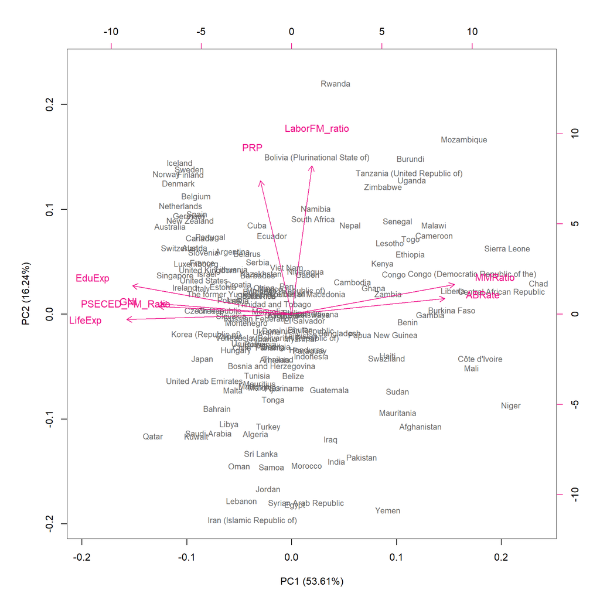

```r
s<-summary(pca_human_standard)
Pros<-round(100*s$importance[2, ], digits = 2)
Pros<-paste0(names(Pros), " (", Pros, "%)")


biplot(pca_human_standard, choices = 1:2, cex = c(0.8, 1), col = c("grey40", "deeppink2"), xlab= Pros[1], ylab=Pros[2])
```

```r
pca_loading(pca_human_standard)
```

```
## Standard deviations (1, .., p=8):
## [1] 2.0708380 1.1397204 0.8750485 0.7788630 0.6619563 0.5363061 0.4589994
## [8] 0.3222406
##
## Rotation (n x k) = (8 x 8):
##                         PC1         PC2         PC3         PC4        PC5
## PSECED_FM_Ratio -0.35664370  0.03796058 -0.24223089 -0.62678110  0.5983585
## LaborFM_ratio    0.05457785  0.72432726 -0.58428770 -0.06199424 -0.2625067
## EduExp          -0.42766720  0.13940571 -0.07340270  0.07020294 -0.1659678
## LifeExp         -0.44372240 -0.02530473  0.10991305  0.05834819 -0.1628935
## GNI             -0.35048295  0.05060876 -0.20168779  0.72727675  0.4950306
## MMRatio          0.43697098  0.14508727 -0.12522539  0.25170614  0.1800657
## ABRate           0.41126010  0.07708468  0.01968243 -0.04986763  0.4672068
## PRP             -0.08438558  0.65136866  0.72506309 -0.01396293  0.1523699
##                         PC6         PC7         PC8
## PSECED_FM_Ratio  0.17713316  0.05773644  0.16459453
## LaborFM_ratio   -0.03500707 -0.22729927 -0.07304568
## EduExp          -0.38606919  0.77962966 -0.05415984
## LifeExp         -0.42242796 -0.43406432  0.62737008
## GNI              0.11120305 -0.13711838 -0.16961173
## MMRatio          0.17370039  0.35380306  0.72193946
## ABRate          -0.76056557 -0.06897064 -0.14335186
## PRP              0.13749772  0.00568387 -0.02306476
```

**Task 5: The tea data comes from the FactoMineR package and it is measured with a questionnaire on tea: 300 individuals were asked how they drink tea (18 questions) and what are their product’s perception (12 questions). In addition, some personal details were asked (4 questions).**